# Prediction Assignment

Weight Lifting Exercise Dataset

Hatem Nassrat

October 20, 2014

## Background

Some background introducing the problem taken directly from the assignment:

> Using devices such as Jawbone Up, Nike FuelBand, and Fitbit it is now possible to collect a large amount of data about personal activity relatively inexpensively. These type of devices are part of the quantified self movement – a group of enthusiasts who take measurements about themselves regularly to improve their health, to find patterns in their behavior, or because they are tech geeks. One thing that people regularly do is quantify how much of a particular activity they do, but they rarely quantify how well they do it. In this project, your goal will be to use data from accelerometers on the belt, forearm, arm, and dumbell of 6 participants. They were asked to perform barbell lifts correctly and incorrectly in 5 different ways. More information is available from the website here: http://groupware.les.inf.puc-rio.br/har (see the section on the Weight Lifting Exercise Dataset).

This prediction assignment aims to correctly predict whether a weight lifting excersize was performed correctly (classe `A`) or incorrectly. If incorrect also determines how it was incorrect (classe `B`, `C`, `D`, `E`).

> Participants were asked to perform one set of 10 repetitions of the Unilateral Dumbbell Biceps Curl in ve di erent fashions: exactly according to the speci cation (Class A), throwing the elbows to the front (Class B), lifting the dumbbell only halfway (Class C), lowering the dumbbell only halfway (Class D) and throwing the hips to the front (Class E). Class A corresponds to the speci ed execution of the exercise, while the other 4 classes correspond to common mistakes. Participants were supervised by an experienced weight lifter to make sure the execution complied to the manner they were supposed to simulate. – [[Velloso 2013]](http://groupware.les.inf.puc-rio.br/work.jsf?p1=11201)

## Data and Approach Overview

The dataset used in this excersize is a subset of the full WLE dataset. A labeled training set around 20,000 entries long and an unlabelled test set 20 entries long were provided for this excersize.

After inspecting the dataset and reading [[Velloso 2013]](http://groupware.les.inf.puc-rio.br/work.jsf?p1=11201) it was apparent that the dataset is a continous flow of data with a sliding window that was snapshot every 2.5s. At the snapshot some aggregate variables (mean, max, min, skewness, …) were calculated. These aggregates of the sliding window is what [[Velloso 2013]](http://groupware.les.inf.puc-rio.br/work.jsf?p1=11201) used to create their predictor and achieved a near perfect prediction model. Unfortunaley after inspecting the test set, it is comprised of single datapoints and not ones with `new_window == 'yes'` therefore not including any of the aggregate parameters.

To approach this problem two methods can be attempted. The first is to ignore the aggregated variables and just use the raw data to predict the `classe` of the excersize. The second is to find and use a good data imputer that can then be used on the test set to impute the missing aggregate data. With each approach multiple models will be tested. Finally the best of all the models would be delivered.

## Data Reading and Clensing

Should be self explanatory, will leave you with the following code snippet

```r
## Project init code
project_dir <- '~/projects/predmachlearn/project'
library(data.table)
library(caret)
set.seed(622253) # for reproducability

## Data Loading Functions

pml.fread <- function(fn) {
  # data.table file read wrapper
  na <- c('NA', '', '#DIV/0!') # seen in the csv
  pml_data <- fread(paste(project_dir, fn, sep='/'), na.strings=na)
  return(pml_data)
}

pml.read.agg <- function(fn) {
  # reading data for approach 2
  pml_data <- pml.fread(fn)
  pml_data <- pml_data[, -c(1:7), with=FALSE]
  if (!is.null(pml_data$classe)) {
    # this field is not present for testing set
    pml_data$classe <- as.factor(pml_data$classe)
  }
  return(pml_data)
}

pml.read.noagg <- function(fn) {
  # reading data for approach 1
  pml_data <- pml.read.agg(fn)
  pml_data <- pml_data[,
    !grepl(
      '^(kurtosis|skewness|max|min|amplitude|var|avg|stddev)_',
      colnames(pml_data)
    ),
    with=FALSE
  ]
  return(pml_data)
}
```

to properly estimate the out of sample error the data needs to be split into a training set and test set. From the course best practices, a 60/40 split will be used.

```r
pml.split <- function(pml_data) {
  # returns the indices of training data
  return(createDataPartition(pml_data$classe, p = 0.6)[[1]])
}
```

## Model Gen and Parameter Tuning via Cross Validation

Using the training data only (60% of the full labelled dataset), training of the model will be perfomed. Repeated Cross Validation will be done during training to pick the best parameters for each model used. Further the best model accross all algorithms tested and cross validated will be choosen. Above two approaches were described, the first approach of removing the agg data columns will be used.

First step is to load the data and sample/split it

```r
pml_data_noagg <- pml.read.noagg('data/pml-training.csv')
train_i <- pml.split(pml_data_noagg)
pml_train <- pml_data_noagg[train_i,]
pml_test <- pml_data_noagg[-train_i,]
dim(pml_train)
## [1] 11776    53
dim(pml_test)
## [1] 7846   53
```

Check data to see if there are any predictors still around that are not needed

```r
library(FSelector)
information.gain(classe ~ ., data=pml_train) > 0
##                      attr_importance
## roll_belt                       TRUE
## pitch_belt                      TRUE
## yaw_belt                        TRUE
## total_accel_belt                TRUE
## gyros_belt_x                    TRUE
## gyros_belt_y                    TRUE
## gyros_belt_z                    TRUE
## accel_belt_x                    TRUE
## accel_belt_y                    TRUE
## accel_belt_z                    TRUE
## magnet_belt_x                   TRUE
## magnet_belt_y                   TRUE
## magnet_belt_z                   TRUE
## roll_arm                        TRUE
## pitch_arm                       TRUE
## yaw_arm                         TRUE
## total_accel_arm                 TRUE
## gyros_arm_x                     TRUE
## gyros_arm_y                     TRUE
## gyros_arm_z                     TRUE
## accel_arm_x                     TRUE
## accel_arm_y                     TRUE
## accel_arm_z                     TRUE
## magnet_arm_x                    TRUE
## magnet_arm_y                    TRUE
## magnet_arm_z                    TRUE
## roll_dumbbell                   TRUE
## pitch_dumbbell                  TRUE
## yaw_dumbbell                    TRUE
## total_accel_dumbbell            TRUE
## gyros_dumbbell_x                TRUE
## gyros_dumbbell_y                TRUE
## gyros_dumbbell_z                TRUE
## accel_dumbbell_x                TRUE
## accel_dumbbell_y                TRUE
## accel_dumbbell_z                TRUE
## magnet_dumbbell_x               TRUE
## magnet_dumbbell_y               TRUE
## magnet_dumbbell_z               TRUE
## roll_forearm                    TRUE
## pitch_forearm                   TRUE
## yaw_forearm                     TRUE
## total_accel_forearm             TRUE
## gyros_forearm_x                 TRUE
## gyros_forearm_y                 TRUE
## gyros_forearm_z                 TRUE
## accel_forearm_x                 TRUE
## accel_forearm_y                 TRUE
## accel_forearm_z                 TRUE
## magnet_forearm_x                TRUE
## magnet_forearm_y                TRUE
## magnet_forearm_z                TRUE
```

```r
pml_pca <- preProcess(pml_train[,!'classe',with=FALSE], method='pca', thresh=0.8)
pml_pca
##
## Call:
## preProcess.default(x = pml_train[, !"classe", with = FALSE], method
##  = "pca", thresh = 0.8)
##
## Created from 11776 samples and 52 variables
## Pre-processing: principal component signal extraction, scaled, centered
##
## PCA needed 13 components to capture 80 percent of the variance
```

to achieve 80% of the variance, the dimensions were reduced as can be seen above. The data is then transformed with pca.

```r
pml_train_pca <- predict(pml_pca, pml_train[, !"classe", with = FALSE])
pml_train_pca$classe <- pml_train$classe
```

The goal is to test both pca and non-pca data with the algorithms below, it was quickly apparent for this approach, pca reduced the quality of the data. Therefore for most test runs only non-pca data will be used. See the first two algorithm runs to see the comparison.

### Algorithms

To pick a winner, the following classification algorithms will be tested

| model | method | type | packages | tuning params |
| --- | --- | --- | --- | --- |
| k-Nearest Neighbors | kknn | Dual Use | kknn |  |
| CART | rpart | Dual Use | rpart | cp |
| Multivariate Adaptive Reg Spline | earth | Dual Use | earth | nprune, degree |
| SVM with Radial Basis Function Kernel | svmRadialCost | Dual Use | kernlab | C |
| C5.0 | C5.0 | Classification | C50, plyr | trials, model, winnow |
| Penalized Multinomial Regression | multinom | Classification | nnet | decay |
| Random Forest | rf | Dual Use | randomForest | mtry |
| Partial Least Squares | kernelpls | Dual Use | pls | ncomp |

> sampled from [caret model list](http://topepo.github.io/caret/modelList.html)

### Training and Tuning with Cross Validation

```r
pml.train.any <- function(pml_data, method, suffix, tuneGrid=NULL) {
  # tuneGrid arg was an after thought, wasn't really used, but good to have
  tc <- trainControl("repeatedcv", repeats=5, selectionFunction="oneSE", num=5)
  modFit <- train(
    classe ~ ., data=pml_data, method = method, tuneGrid=tuneGrid,
    trControl = tc, metric = "Accuracy")
  save(modFit, file=paste0(project_dir, '/models/', method, suffix, '.Rdata'))
  return(modFit)
}
```

#### CART: rpart

```r
# modFit <- pml.train.any(pml_train_pca, method='rpart', '_noagg_pca')
# modFit <- pml.train.any(pml_train_pca, method='rpart', '_noagg')
```

The orig data without PCA performed better. Here are the cross validation results for the resulting CART model. The best model performed with around in-sample 50% accuracy accross the classes (with PCA the accuracy was 36%).

```
CART

11776 samples
   52 predictor
    5 classes: 'A', 'B', 'C', 'D', 'E'

No pre-processing
Resampling: Cross-Validated (5 fold, repeated 5 times)

Summary of sample sizes: 9421, 9420, 9421, 9421, 9421, 9420, ...

Resampling results across tuning parameters:

  cp      Accuracy  Kappa   Accuracy SD  Kappa SD
  0.0344  0.504     0.3528  0.0136       0.0182
  0.0615  0.438     0.2446  0.0640       0.1071
  0.1164  0.316     0.0489  0.0399       0.0612

Accuracy was used to select the optimal model using  the one SE rule.
The final value used for the model was cp = 0.03440911.
```

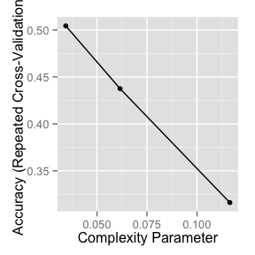

#### k-Nearest Neighbors: kknn

```r
# modFit <- pml.train.any(pml_train_pca, method='kknn', '_noagg_pca')
# modFit <- pml.train.any(pml_train, method='kknn', '_noagg')
```

Again the orig data without PCA performed better. Here are the cross validation results for the resulting KNN model. The best model performed with around 98% in-sample accuracy accross the classes (with PCA the accuracy was 95%).

```
k-Nearest Neighbors

11776 samples
   52 predictor
    5 classes: 'A', 'B', 'C', 'D', 'E'

No pre-processing
Resampling: Cross-Validated (5 fold, repeated 5 times)

Summary of sample sizes: 9422, 9421, 9420, 9421, 9420, 9420, ...

Resampling results across tuning parameters:

  kmax  Accuracy  Kappa  Accuracy SD  Kappa SD
  5     0.981     0.976  0.00244      0.00308
  7     0.981     0.976  0.00244      0.00308
  9     0.981     0.976  0.00244      0.00308

Tuning parameter 'distance' was held constant at a value of 2

Tuning parameter 'kernel' was held constant at a value of optimal
Accuracy was used to select the optimal model using  the one SE rule.
The final values used for the model were kmax = 9, distance = 2 and
 kernel = optimal.
```

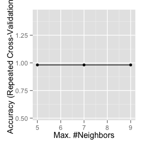

Moving forward only non pca data will be used due to these findings.

#### Multinomial Regression: multinom

Accuracy of 64% with repeated cross validation and parameter tuning was the best produced model. The full details below.

```r
# modFit <- pml.train.any(pml_train, method='multinom', '_noagg')
```

```
Penalized Multinomial Regression

11776 samples
   52 predictor
    5 classes: 'A', 'B', 'C', 'D', 'E'

No pre-processing
Resampling: Cross-Validated (5 fold, repeated 5 times)

Summary of sample sizes: 9421, 9421, 9421, 9420, 9421, 9420, ...

Resampling results across tuning parameters:

  decay  Accuracy  Kappa  Accuracy SD  Kappa SD
  0e+00  0.641     0.545  0.013        0.0164
  1e-04  0.641     0.545  0.013        0.0164
  1e-01  0.641     0.545  0.013        0.0164

Accuracy was used to select the optimal model using  the one SE rule.
The final value used for the model was decay = 0.1.
```

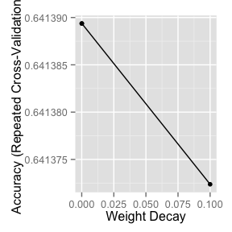

#### C5.0

Cross validation produced a model with an accuracy of 99%. The details follow.

```r
# modFit <- pml.train.any(pml_train, method='C5.0', '_noagg')
```

```
C5.0

11776 samples
   52 predictor
    5 classes: 'A', 'B', 'C', 'D', 'E'

No pre-processing
Resampling: Cross-Validated (5 fold, repeated 5 times)

Summary of sample sizes: 9421, 9422, 9420, 9420, 9421, 9420, ...

Resampling results across tuning parameters:

  model  winnow  trials  Accuracy  Kappa  Accuracy SD  Kappa SD
  rules  FALSE    1      0.950     0.937  0.00515      0.00652
  rules  FALSE   10      0.988     0.984  0.00245      0.00310
  rules  FALSE   20      0.991     0.988  0.00176      0.00223
  rules   TRUE    1      0.950     0.937  0.00432      0.00547
  rules   TRUE   10      0.988     0.984  0.00236      0.00299
  rules   TRUE   20      0.991     0.989  0.00189      0.00240
  tree   FALSE    1      0.943     0.928  0.00608      0.00769
  tree   FALSE   10      0.987     0.983  0.00225      0.00285
  tree   FALSE   20      0.989     0.986  0.00200      0.00253
  tree    TRUE    1      0.944     0.929  0.00595      0.00752
  tree    TRUE   10      0.986     0.983  0.00256      0.00324
  tree    TRUE   20      0.990     0.987  0.00166      0.00210

Accuracy was used to select the optimal model using  the one SE rule.
The final values used for the model were trials = 20, model = rules
 and winnow = TRUE.
```

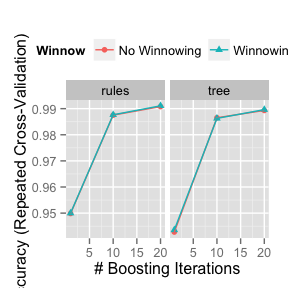

#### svmRadialCost

With all the parameters tuned via cross validation the best model found produced an accuracy of 92%. The details follow.

```r
# modFit <- pml.train.any(pml_train, method='svmRadialCost', '_noagg')
```

```
Support Vector Machines with Radial Basis Function Kernel

11776 samples
   52 predictor
    5 classes: 'A', 'B', 'C', 'D', 'E'

No pre-processing
Resampling: Cross-Validated (5 fold, repeated 5 times)

Summary of sample sizes: 9421, 9421, 9421, 9420, 9421, 9420, ...

Resampling results across tuning parameters:

  C     Accuracy  Kappa  Accuracy SD  Kappa SD
  0.25  0.850     0.810  0.00802      0.01019
  0.50  0.889     0.859  0.00712      0.00904
  1.00  0.917     0.894  0.00597      0.00759

Accuracy was used to select the optimal model using  the one SE rule.
The final value used for the model was C = 1.
```

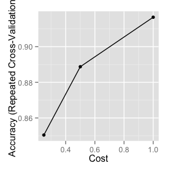

#### MARS: earth

After cross validation the best model found produced an accuracy of 90%. The details follow.

```r
# modFit <- pml.train.any(pml_train, method='earth', '_noagg')
```

```
Multivariate Adaptive Regression Spline

11776 samples
   52 predictor
    5 classes: 'A', 'B', 'C', 'D', 'E'

No pre-processing
Resampling: Cross-Validated (5 fold, repeated 5 times)

Summary of sample sizes: 9421, 9421, 9421, 9420, 9421, 9420, ...

Resampling results across tuning parameters:

  nprune  Accuracy  Kappa  Accuracy SD  Kappa SD
   2      0.354     0.119  0.00487      0.00709
  35      0.832     0.788  0.00868      0.01098
  68      0.898     0.870  0.01621      0.02049

Tuning parameter 'degree' was held constant at a value of 1
Accuracy was used to select the optimal model using  the one SE rule.
The final values used for the model were nprune = 68 and degree = 1.
```

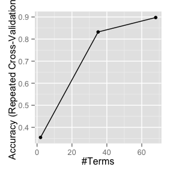

#### Random Forest: rf

99% accuracy was found after cross validation and parameter tuning.

```r
# modFit <- pml.train.any(pml_train, method='rf', '_noagg')
```

```
Random Forest

11776 samples
   52 predictor
    5 classes: 'A', 'B', 'C', 'D', 'E'

No pre-processing
Resampling: Cross-Validated (5 fold, repeated 5 times)

Summary of sample sizes: 9421, 9421, 9421, 9420, 9421, 9420, ...

Resampling results across tuning parameters:

  mtry  Accuracy  Kappa  Accuracy SD  Kappa SD
   2    0.988     0.985  0.00223      0.00282
  27    0.989     0.985  0.00229      0.00290
  52    0.981     0.976  0.00322      0.00408

Accuracy was used to select the optimal model using  the one SE rule.
The final value used for the model was mtry = 2.
```

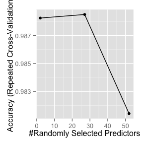

#### Partial Least Squares: kernelpls

The best model found produced an accuracy of 37%, this is by far the worst out of the algorithms that were tested.

```r
# modFit <- pml.train.any(pml_train, method='kernelpls', '_noagg')
```

```
Partial Least Squares

11776 samples
   52 predictor
    5 classes: 'A', 'B', 'C', 'D', 'E'

No pre-processing
Resampling: Cross-Validated (5 fold, repeated 5 times)

Summary of sample sizes: 9421, 9421, 9421, 9420, 9421, 9420, ...

Resampling results across tuning parameters:

  ncomp  Accuracy  Kappa  Accuracy SD  Kappa SD
  1      0.323     0.101  0.00891      0.01194
  2      0.342     0.139  0.00757      0.00938
  3      0.373     0.183  0.01649      0.02126

Accuracy was used to select the optimal model using  the one SE rule.
The final value used for the model was ncomp = 3.
```

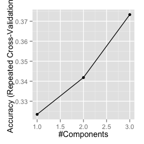

### Out-of-Sample Accuracy

With the 40% of the dataset that was split out of the training set, accuracy of each of the trained model will be determined. The accuracy can be seen in the figure below.

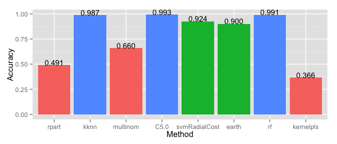

```r
pml.load_model <- function(fn) {
  load(paste0(project_dir, '/models/', fn, '.Rdata'))
  return(modFit)
}
pml.accuracy <- function(modFit, pml_data) {
  res <- predict(modFit, newdata=pml_data) == pml_data$classe
  return(sum(res) / length(res))
}
pml.load_and_acc <- function(fn, pml_data) {
  modFit <- pml.load_model(paste0(fn, '_noagg'))
  return(pml.accuracy(modFit, pml_data))
}
pml.confusion_matrix <- function(modFit, pml_data) {
  res <- predict(modFit, newdata=pml_data)
  return(table(res, pml_data$classe))
}
pml.load_and_confuse <- function(fn, pml_data) {
  modFit <- pml.load_model(paste0(fn, '_noagg'))
  return(pml.confusion_matrix(modFit, pml_data))
}
pml.algos <- c(
  'rpart', 'kknn', 'multinom', 'C5.0',
  'svmRadialCost', 'earth', 'rf', 'kernelpls'
)
res <- lapply(pml.algos,function(x){return(data.frame(Method=x, Accuracy=pml.load_and_acc(x, pml_test)))})
res <- as.data.frame(do.call(rbind, res))
# res[order(res$Accuracy, decreasing=TRUE),]

qplot(Method, Accuracy, data=res, geom='bar', fill=cut_number(Accuracy, 3), stat='identity') +
  geom_text(data=res,aes(label=sprintf('%.3f', Accuracy)), vjust=0, size=4) +
  theme(legend.position="none")
```

As can be seen from the results displayed above, the top three models were using the algorithms *C5.0*, *rf*, *kknn* and were very close regarding their results. The following are the three confusion matricies for these approaches.

```
## [1] "Confusion Matrix for C5.0"
##
## res    A    B    C    D    E
##   A 2229   10    0    0    1
##   B    2 1499    9    2    0
##   C    0    8 1350    8    2
##   D    0    1    8 1274    0
##   E    1    0    1    2 1439
## [1] "Confusion Matrix for rf"
##
## res    A    B    C    D    E
##   A 2229   12    0    0    0
##   B    3 1490    8    0    0
##   C    0   16 1355   24    4
##   D    0    0    5 1262    1
##   E    0    0    0    0 1437
## [1] "Confusion Matrix for kknn"
##
## res    A    B    C    D    E
##   A 2216    8    2    1    0
##   B    7 1488    3    0    4
##   C    5   21 1344   15    5
##   D    3    0   14 1267    2
##   E    1    1    5    3 1431
```

A quick informal speed test showed that *kknn* is considerably slower than the two other algorithms to label a test set. That being said, the test set for the assignment is small enough that it does not matter. In the real world this maybe different, this point is elaborated on in the final remarks.

## Conclusions and Summary

Due to the above findings, the C5.0 model was choosen for the labelling of the assigned unlabbeled data. This is because it produced slightly better results than the tuned Random Forest algorithm which hopefully will give an edge with the unlabelled test cases. It was also seen that both C5.0 and Random Forest algorithms label data quite quickly. For real world scenarios labeling speed is in many cases very important. For the example of where this dataset originated, the user would want to be notified immediately if they are performing an excersize incorrectly so that they can correct themselves.

## Future Work

Briefly an approach was mentioned earlier to make use of the sliding window data. This can be done by combining multiple models. The first model would impute the aggregate data which would also be used to impute the aggregate fields on the test set. The second model would be used to classify the full record, with all its fields into the proper class. A good first candidate for the imputation is knnImpute, and for the classifier is C5.0 since that performed the best results here.